# l7_quant2_ii_en

Research Seminar

ggplot, covariance -> regression

Sergi Martínez

smsoler@clio.uc3m.es | Office hours: Tuesdays from 10:00 to 13:00 (by email)

## Today

- Logistics:
  - Next Monday (26 Oct):
    - I’ll talk about process tracing
    - Start drafting a case/s study section and translate our RQ into qualitative strategies (interviews, focus groups, ethnography)
    - 5-10’ mentorship sessions with each group
  - Next Friday (30 Oct):
    - We’ll talk about ethnography and discuss the overall validity of qualitative methods
    - 3-5’ presentations and feedback rounds
- Today:
  - R: ggplot
  - Statistics
    - Covariance
    - Regression

Before anything else: the data I use in this class comes from the [40dB Barometer](https://elpais.com/espana/2026-10-05/consulte-todos-los-datos-internos-de-la-encuesta-de-el-pais-cuestionarios-cruces-y-respuestas-individuales.html) for El País and Cadena Ser

**ggplot**

| Type of variable | Source of the data | Possible values | Examples |
| --- | --- | --- | --- |
| **Discrete** | Count | Whole numbers (finite or countable) | Number of students, pets |
| **Continuous** | Measurement | Real numbers with decimals | Height, speed, time |
| **Categorical** | Classification | Categories or groups, with or without natural order | Sex, autonomous community, vote, social class (ordered) |

## The big problem

[figure not shown]

## Put another way

[figure not shown]

## An example: excess of “creativity”

[figure not shown]

## An example: excess of “creativity” (a bit less)

[figure not shown]

## Common mistakes

[figure not shown]

## Common mistakes

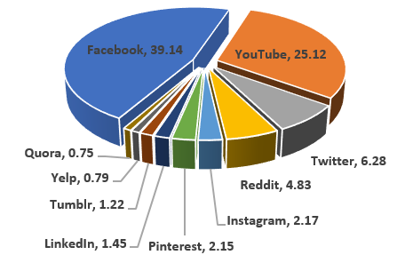

More info: https://scc.ms.unimelb.edu.au/resources/data-visualisation-and-exploration/no_pie-charts

## Another example

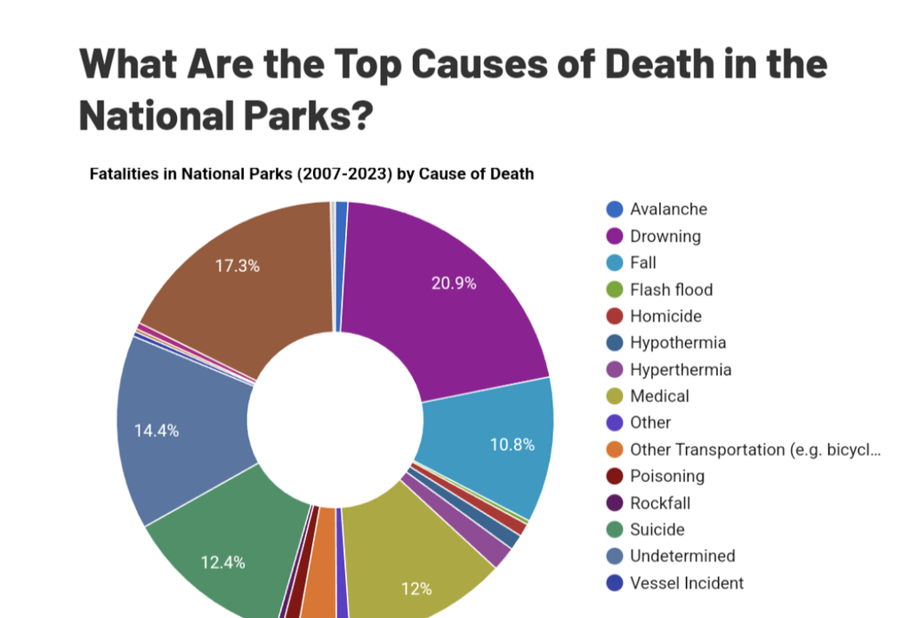

[figure not shown]

Moral: **Do not use pie charts**

## Let’s see another example with 2 axes

[figure not shown]

## Let’s see another example with 2 axes

[figure not shown]

## Can you think of a good example?

**NYT**: What’s going on in this graph?

[figure not shown]

[figure not shown]

## Sometimes you don’t have to look so far

[figure not shown]

## Good examples (II)

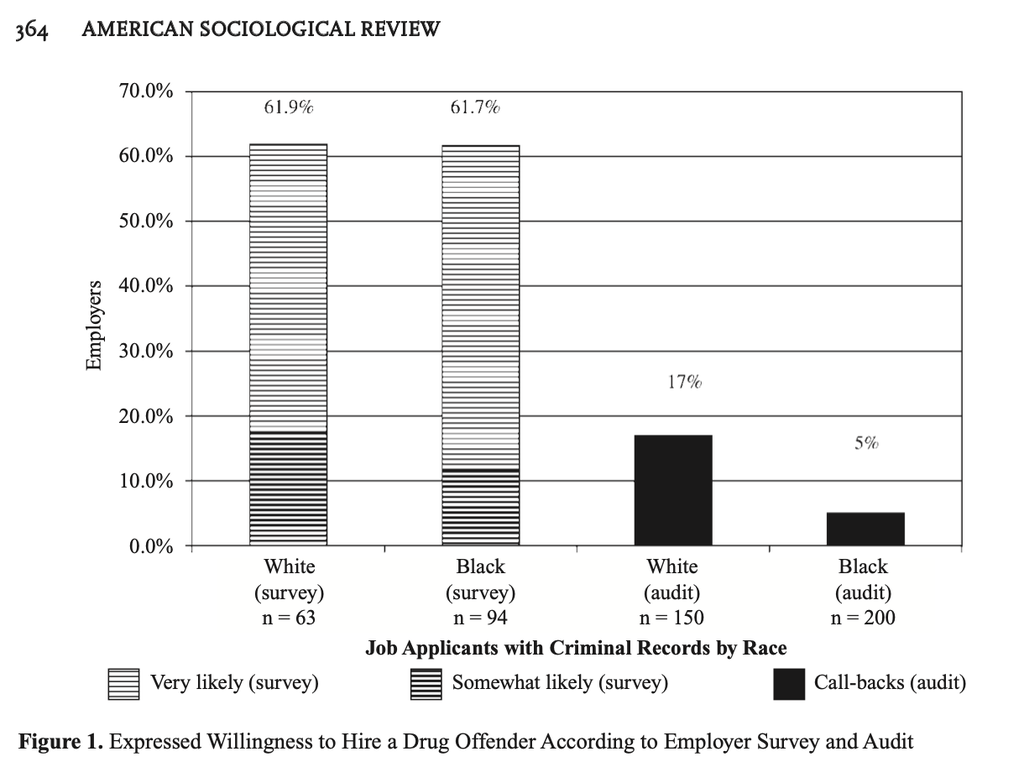

## Good examples (III)

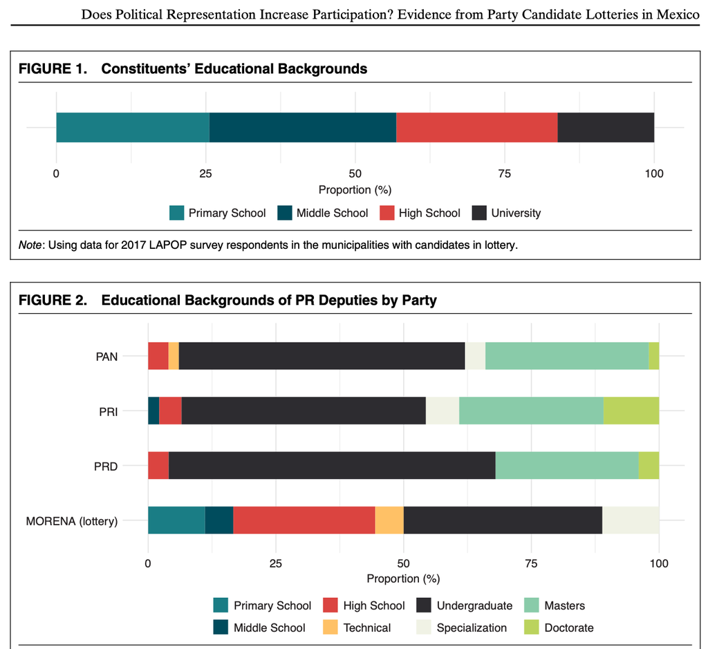